# Does Race type affects a resident’s life

Hu Xiangkun

2014年10月20日

I will study the problem that whether a resident’s race affects his/her life. The reseason I do this project is that, racial discrimination was a big problem in US history, though we advocate the equality for all today, the life of different races may not be the same. So this project will show the racical discrimination’s exsistence in the USA.

In this project, I use the data from General Social Survey (GSS), which conducted between 1972 - 2012 from the residents of United States. The dataset names “gss”. The cases are residents of the USA. This is an observational study. The population are all the residents in the USA.

I will figure this out by contrasting the education and income level between the white and black race.

First let’s load the dataset as below:

```r
#Load data from the working directory
load("gss.Rdata")
```

The gss dataset has 114 variables, there are 3 variable I care about here are “race”, “incom16” and “degree”, so let’s get the subset:

```r
#This project only care about race, income and eduction level
gss_p = na.omit(gss[, c("race", "incom16", "degree")])
```

Let’s see the summary of this subset:

```r
summary(gss_p)
```

```
##     race                       incom16                 degree
##  White:35246   Far Below Average   : 3556   Lt High School: 9628
##  Black: 5826   Below Average       :10421   High School   :22283
##  Other: 1844   Average             :21621   Junior College: 2194
##                Above Average       : 6527   Bachelor      : 5933
##                Far Above Average   :  781   Graduate      : 2878
##                Lived In Institution:   10
```

The summary infomation shows that the main race in the USA are “White” and “Black”, and there are 6 types of income level and 5 types of eduction level. So here I only concern “White” and “Black” race for this study.

```r
#Only concern about "White" and "Black" race
data = subset(gss_p, gss_p$race == "White" | gss_p$race == "Black")
summary(data)
```

```
##     race                       incom16                 degree
##  White:35246   Far Below Average   : 3254   Lt High School: 9121
##  Black: 5826   Below Average       : 9894   High School   :21513
##  Other:    0   Average             :20875   Junior College: 2078
##                Above Average       : 6301   Bachelor      : 5654
##                Far Above Average   :  738   Graduate      : 2706
##                Lived In Institution:   10
```

So next I will use hypothsis test and confidence interval to test whether there is a difference between White and Black in income and eduction level.

# Income

There are 6 income levels, I will study them one by one. As the method in study different types are the same, so I will use the income level “Far Below Average” as an example.

#### Far Below Average

Using **pw** and **pb** to represent the probabilty of the resident has a income far below the average. Cause I will use hypothsis test, now I state the hypothsis below:

**H0: Race has no effect in income level far below average, the two probabilties are equal, i.e. pw = pb**

**HA: Race type does has an effect, i.e. pw ≠ pb**

First check the conditions.

```r
#Subset of data with income far below average
data_income_farbelow = subset(data, data$incom16 == "Far Below Average")
nw = nrow(subset(data_income_farbelow, data_income_farbelow$race == "White"))
nb = nrow(subset(data_income_farbelow, data_income_farbelow$race == "Black"))
nw
```

```
## [1] 2224
```

```r
nb
```

```
## [1] 1030
```

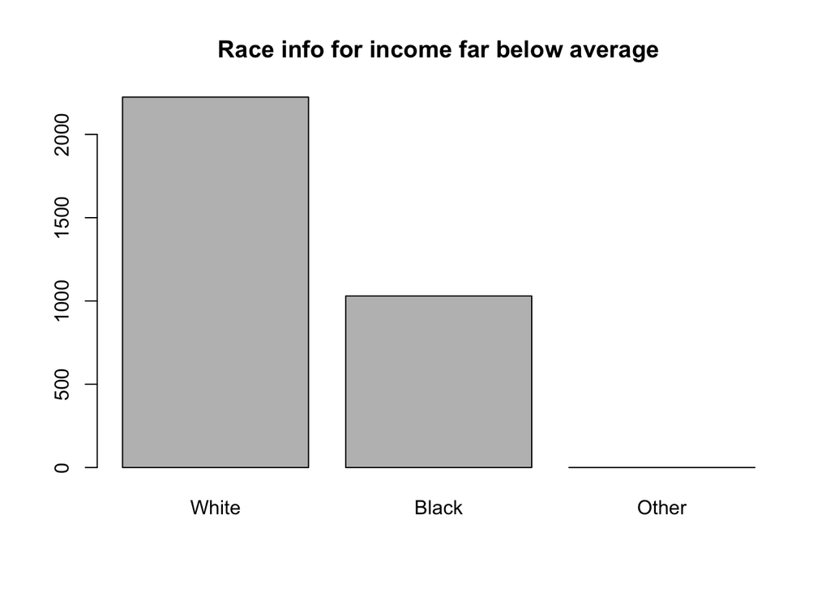

Since the data are collect randomly, and the number of “White” and “Black” are all greater than 10, so the success-failure condition holds. We can say that the observations are all independent and nearly normal.

Now let’s calculate the point estimate of **pw-pb**:

```r
#Point estimate of pw and pb.
pw_e = nw / nrow(data)
pb_e = nb / nrow(data)
#Point estimate of pw-pe
pe = pw_e - pb_e
#standard error
se = sqrt(pw_e*(1 - pw_e)/nw + pb_e*(1 - pb_e)/nb)
#confidence interval using 95% confidence level
c(pe-1.96*se, pe+1.96*se)
```

```
## [1] 0.01566731 0.04247449
```

```r
#p-value using 5% significance level
2*(1 - pnorm(pe/se))
```

```
## [1] 2.127973e-05
```

In fact, I can write a function that can be used in all the income levels. Here is the function:

```r
income_evaluate = function(incomelevel = "Far Below Average") {
  #subset of the given income level
  subdata = subset(data, data$incom16 == incomelevel)
  nw = nrow(subset(subdata, subdata$race == "White"))
  nb = nrow(subset(subdata, subdata$race == "Black"))
  #point estimate of the pw-pb
  pw_e = nw / nrow(data)
  pb_e = nb / nrow(data)
  pe = pw_e - pb_e
  #standard error
  se = sqrt(pw_e*(1 - pw_e)/nw + pb_e*(1 - pb_e)/nb)
  #confidence interval using 95% confidence level
  print(paste("Confidence Interval: (", as.character(pe-1.96*se), ", ", as.character(pe+1.96*se), ")", sep=""))
  #p-value using 5% significance level
  print(paste("p-value: ", as.character(2*(1 - pnorm(pe/se)))))
}
```

```r
income_evaluate("Far Below Average")
```

```
## [1] "Confidence Interval: (0.0156673079310977, 0.0424744918351664)"
## [1] "p-value:  2.1279729710777e-05"
```

We can see the result is the same as above. Now we calculate the confidence interval and p-value for other income levels.

#### Below Average

```r
income_evaluate("Below Average")
```

```
## [1] "Confidence Interval: (0.136812537539344, 0.162466776835412)"
## [1] "p-value:  0"
```

#### Average

```r
income_evaluate("Average")
```

```
## [1] "Confidence Interval: (0.381472767768267, 0.405097158215372)"
## [1] "p-value:  0"
```

#### Above Average

```r
income_evaluate("Above Average")
```

```
## [1] "Confidence Interval: (0.11830988718176, 0.144594281108073)"
## [1] "p-value:  0"
```

#### Far Above Average

```r
income_evaluate("Far Above Average")
```

```
## [1] "Confidence Interval: (-0.00100365308781903, 0.0262276499713407)"
## [1] "p-value:  0.0694437050999919"
```

The above result shows that except the “Far Above Average” level, other levels all reject the null hypothsis.

# Education

The evaluating for education levels is just the same as the evaluation for the income level.

First, I will write a function to calculate the confidence interval and p-value.

```r
education_evaluate = function(educationlevel = "Lt High School") {
  #subset of the given edu level
  subdata = subset(data, data$degree == educationlevel)
  nw = nrow(subset(subdata, subdata$race == "White"))
  nb = nrow(subset(subdata, subdata$race == "Black"))
  #point estimate of the pw-pb
  pw_e = nw / nrow(data)
  pb_e = nb / nrow(data)
  pe = pw_e - pb_e
  #standard error
  se = sqrt(pw_e*(1 - pw_e)/nw + pb_e*(1 - pb_e)/nb)
  #confidence interval using 95% confidence level
  print(paste("Confidence Interval: (", as.character(pe-1.96*se), ", ", as.character(pe+1.96*se), ")", sep=""))
  #p-value using 5% significance level
  print(paste("p-value: ", as.character(2*(1 - pnorm(pe/se)))))
}
```

Now I use this function to calculate the confidence interval and p-value for each education level.

#### Lt High School

```r
education_evaluate("Lt High School")
```

```
## [1] "Confidence Interval: (0.117777409030773, 0.143568520069344)"
## [1] "p-value:  0"
```

#### High School

```r
education_evaluate("High School")
```

```
## [1] "Confidence Interval: (0.368094616462822, 0.391595683498222)"
## [1] "p-value:  0"
```

#### Junior College

```r
education_evaluate("Junior College")
```

```
## [1] "Confidence Interval: (0.0203398824591491, 0.0473461323441232)"
## [1] "p-value:  8.99837894641209e-07"
```

#### Bachelor

```r
education_evaluate("Bachelor")
```

```
## [1] "Confidence Interval: (0.10274460019098, 0.129140869228576)"
## [1] "p-value:  0"
```

#### Graduate

```r
education_evaluate("Graduate")
```

```
## [1] "Confidence Interval: (0.0425491562644319, 0.0694492854963784)"
## [1] "p-value:  4.44089209850063e-16"
```

The outputs show that all the evaluations reject the null hypothsis. Now we can see that “White” are more than “Black” in all education level.

*So we can make the conclusion that the race type does affect the residents’ life in the USA.*

# References

The data set can be downloaded by this link: http://d396qusza40orc.cloudfront.net/statistics/project/gss.Rdata

# Appendix

[output not shown]

[output cut: 16 more lines]